# Great Gadget, or Gimmick? Which Gadget do I use? What do I use it for?

In this notebook, some data collected from fitness trackers and compiled in Strava will be explored with various visulaziation techniques that will successively uncover clues to further exploration at each step. The goal here is to not only **tell a story for an audience*** of current and potential fitness tracker enthusiasts, but to also **document the process, not just the results*** of the manipulation and interpretation of the data and its visualization. The process of data manipulation and visualization is best exemplified in this Jupyter notebook platform, where we can **use cell divisions to make steps clear*** and easily **share and explain the data***. We will start by **recording dependencies*** such as the `pandas`, `matplotlib`, and `seaborn` libraries used for data manipulation and visualization, as well as the source data.

**Tell a story for an audience***  
Many great stories begin with powerful and provocative questions: like the three questions that appear as the title of this notebook. The paragraph immediately preceeding this one introduces the aim of performing this analysis in the first place: to sequentially uncover evermore granular questions as we explore tabular fitness date devoid of the commerically available visualization tools.  
Our client already has commerically availabe visualization tools at their disposal, but has asked us to use a wider and more sophisticated set of data manipulation and visualization tools to uncover questions and answers through exploration rather than through prescriptive methodologies. As it has been in this exploration with questioning whether or not a data was measured or calculated (Section 1.3), existing representations of data can be both challenged and refined.

**Use cell divisions to make steps clear***  
In this notebook, this process began after the very first visualization - which is a simple matrix of boxplots - providing the vital 5-number summaries and general shape and distribution for each variable under consideration for problem description and problem solving.  
As with all visualizations in this notebook, a short justification for engaging in the visualization process precedes the heading for the plot. After the heading "announces" the plot, a step-by-step guide is given for any data manipulation needed, and then a step-by-step implementation of the plot mechanics is introduced. When possible, special attention to essential function and method arguments are contained in a Markdown cell immediately preceeding the cell in which they are executed. If several lines of code with essential arguments need to be executed together (as with axes functions and methods), then a descriptive paragraph annotated with line numbers proceeds the block of code.  
Perhaps the most important cells are those between plots and headers that "announce" development of a new plot. It is here that insights from intermediate processes are given attention through a summary of findings and the manner and means by which these data will move the overall process forward.

**Rule A, Birmingham A, Zuniga C, Altintas I, Huang S-C, Knight R, et al. (2019) Ten simple rules for writing and sharing computational analyses in Jupyter Notebooks. PLoS Comput Biol 15(7): e1007007. https://doi.org/10.1371/journal.pcbi.1007007*

## Dependencies: Necessary Data and Libraries

For this exploration, the following packages will need to be installed in the Python environment with `pip install package` (or using conda if you so choose):

- `pandas as pd` for data manipulation and analysis
- `matplotlib.pyplot as plt` to use the plotting framework of matplotlib
- `seaborn as sns` for some additional statistical data visualization tools  
  Working in a Python Notebook, simply import these libraries in the usual way:

```python
import pandas as pd
import matplotlib.pyplot as plt
import seaborn as sns
```

Next, we will need to read in the Strava data (resources/assets/strava.csv) and place it into a Pandas dataframe object:

```python
df = pd.read_csv('resources/assets/strava.csv')
df.head()
```

|  | Air Power | Cadence | Form Power | Ground Time | Leg Spring Stiffness | Power | Vertical Oscillation | altitude | cadence | datafile | ... | enhanced_speed | fractional_cadence | heart_rate | position_lat | position_long | speed | timestamp | unknown_87 | unknown_88 | unknown_90 |
| --- | --- | --- | --- | --- | --- | --- | --- | --- | --- | --- | --- | --- | --- | --- | --- | --- | --- | --- | --- | --- | --- |
| 0 | NaN | NaN | NaN | NaN | NaN | NaN | NaN | NaN | 0.0 | activities/2675855419.fit.gz | ... | 0.000 | 0.0 | 68.0 | NaN | NaN | 0.0 | 2019-07-08 21:04:03 | 0.0 | 300.0 | NaN |
| 1 | NaN | NaN | NaN | NaN | NaN | NaN | NaN | NaN | 0.0 | activities/2675855419.fit.gz | ... | 0.000 | 0.0 | 68.0 | NaN | NaN | 0.0 | 2019-07-08 21:04:04 | 0.0 | 300.0 | NaN |
| 2 | NaN | NaN | NaN | NaN | NaN | NaN | NaN | NaN | 54.0 | activities/2675855419.fit.gz | ... | 1.316 | 0.0 | 71.0 | NaN | NaN | 1316.0 | 2019-07-08 21:04:07 | 0.0 | 300.0 | NaN |
| 3 | NaN | NaN | NaN | NaN | NaN | NaN | NaN | 3747.0 | 77.0 | activities/2675855419.fit.gz | ... | 1.866 | 0.0 | 77.0 | 504432050.0 | -999063637.0 | 1866.0 | 2019-07-08 21:04:14 | 0.0 | 100.0 | NaN |
| 4 | NaN | NaN | NaN | NaN | NaN | NaN | NaN | 3798.0 | 77.0 | activities/2675855419.fit.gz | ... | 1.894 | 0.0 | 80.0 | 504432492.0 | -999064534.0 | 1894.0 | 2019-07-08 21:04:15 | 0.0 | 100.0 | NaN |

5 rows × 22 columns

## Data Manipulation

Because we will be exploring this data with some time-series visualization methods, we can manipulate the data for these purposes before we get started with visualizations:

- We will split the `timestamp` column and store only the date in the `date` column so that we can perform time series visualization methods:

```python
datesplit = df['timestamp'].str.split(' ', expand = True)
df['date'] = datesplit[0]

df.head()
```

|  | Air Power | Cadence | Form Power | Ground Time | Leg Spring Stiffness | Power | Vertical Oscillation | altitude | cadence | datafile | ... | fractional_cadence | heart_rate | position_lat | position_long | speed | timestamp | unknown_87 | unknown_88 | unknown_90 | date |
| --- | --- | --- | --- | --- | --- | --- | --- | --- | --- | --- | --- | --- | --- | --- | --- | --- | --- | --- | --- | --- | --- |
| 0 | NaN | NaN | NaN | NaN | NaN | NaN | NaN | NaN | 0.0 | activities/2675855419.fit.gz | ... | 0.0 | 68.0 | NaN | NaN | 0.0 | 2019-07-08 21:04:03 | 0.0 | 300.0 | NaN | 2019-07-08 |
| 1 | NaN | NaN | NaN | NaN | NaN | NaN | NaN | NaN | 0.0 | activities/2675855419.fit.gz | ... | 0.0 | 68.0 | NaN | NaN | 0.0 | 2019-07-08 21:04:04 | 0.0 | 300.0 | NaN | 2019-07-08 |
| 2 | NaN | NaN | NaN | NaN | NaN | NaN | NaN | NaN | 54.0 | activities/2675855419.fit.gz | ... | 0.0 | 71.0 | NaN | NaN | 1316.0 | 2019-07-08 21:04:07 | 0.0 | 300.0 | NaN | 2019-07-08 |
| 3 | NaN | NaN | NaN | NaN | NaN | NaN | NaN | 3747.0 | 77.0 | activities/2675855419.fit.gz | ... | 0.0 | 77.0 | 504432050.0 | -999063637.0 | 1866.0 | 2019-07-08 21:04:14 | 0.0 | 100.0 | NaN | 2019-07-08 |
| 4 | NaN | NaN | NaN | NaN | NaN | NaN | NaN | 3798.0 | 77.0 | activities/2675855419.fit.gz | ... | 0.0 | 80.0 | 504432492.0 | -999064534.0 | 1894.0 | 2019-07-08 21:04:15 | 0.0 | 100.0 | NaN | 2019-07-08 |

5 rows × 23 columns

## Visualization 1: Box Plots, 5-Number Summary

A Box Plot of each column in the Strava data will give a summary of the non-grouped, continuous data. This summary most notably incldues the 5-number summary: the minimum value, the maximum value, the mean and the first and third quartiles for the data. While a histogram would show more detailed information about the data distribution, a box plot is the best place to start because it can help make decisions about how to group data to uncover any variations such as a particular skew direction. What little information is lost by choosing box plots in lieu of histograms is regained by using an argument in our Matplotlib's box plots to display the mean in addition to the median.

At this point in the exploration, we are attempting to assess some of the claims made by the manufacturer of one of the monitors used to produce the exercise data we are exploring. According to the claims, the device helps in the detection of "increases [or decreases, presumably] in fitness and efficiency."* Since these claims pertain to variation across multiple sessions of exercise, we can group our data by these sessions and transform each variable by taking the mean of each of the variables within each session. While this approach is not valid for future exploration of this data, it simplifies our visualization tasks and meets our goals where we are simply interested in how each variable (column of data) varies in relation to other variables across sessions (or time).

*https://www.stryd.com/guide

As such, here we will create a new dataframe (`dfgrouped`) by grouping our data based on the `date` column and applying a method that takes the mean of each of the variable's values tabulated under that date (or, session):

```python
dfgrouped = df.groupby(['date']).mean()
dfgrouped.head()
```

| date | Air Power | Cadence | Form Power | Ground Time | Leg Spring Stiffness | Power | Vertical Oscillation | altitude | cadence | distance | enhanced_altitude | enhanced_speed | fractional_cadence | heart_rate | position_lat | position_long | speed | unknown_87 | unknown_88 | unknown_90 |
| --- | --- | --- | --- | --- | --- | --- | --- | --- | --- | --- | --- | --- | --- | --- | --- | --- | --- | --- | --- | --- |
| 2019-07-08 | NaN | NaN | NaN | NaN | NaN | NaN | NaN | 3823.037037 | 74.406504 | 1231.628293 | 264.607407 | 2.088154 | 0.117886 | 118.337398 | 5.044823e+08 | -9.991914e+08 | 2088.154472 | 0.0 | 294.308943 | 1.711340 |
| 2019-07-10 | NaN | NaN | NaN | NaN | NaN | NaN | NaN | 3776.640449 | 79.314607 | 400.068652 | 255.328090 | 2.581567 | 0.044944 | 130.123596 | 5.042875e+08 | -9.990872e+08 | 2581.567416 | 0.0 | 295.505618 | NaN |
| 2019-07-12 | NaN | NaN | NaN | NaN | NaN | NaN | NaN | 3854.755214 | 74.135016 | 3585.156685 | 270.951043 | 1.966212 | 0.228321 | 117.687157 | 5.045312e+08 | -9.993456e+08 | 1966.211855 | 0.0 | 299.780461 | NaN |
| 2019-07-14 | NaN | NaN | NaN | NaN | NaN | NaN | NaN | 3871.658333 | 75.553472 | 3535.234931 | 274.331667 | 1.845992 | 0.251389 | 113.642361 | 5.044322e+08 | -9.989680e+08 | 1845.992361 | 0.0 | 300.000000 | -2.100775 |
| 2019-07-16 | NaN | NaN | NaN | NaN | NaN | NaN | NaN | 3809.887574 | 76.100000 | 592.994176 | 261.977515 | 2.380412 | 0.088235 | 118.858824 | 5.045098e+08 | -9.990084e+08 | 2380.411765 | 0.0 | 290.588235 | NaN |

Now our data is ready for visualization with box plots:

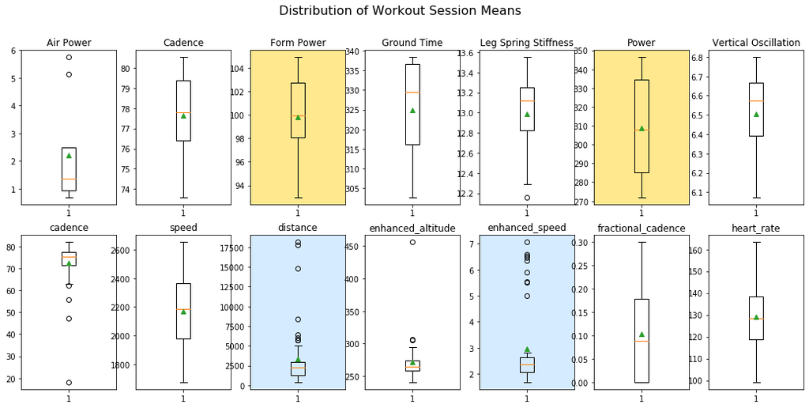

```python
fig, axes = plt.subplots(ncols=7, nrows=2, figsize=(18,8))
fig.suptitle('Distribution of Workout Session Means', fontsize=16)
axes[0,0].boxplot(dfgrouped['Air Power'].dropna(), showmeans=True)
axes[0,0].set_title('Air Power')
axes[0,1].boxplot(dfgrouped['Cadence'].dropna(), showmeans=True)
axes[0,1].set_title('Cadence')
axes[0,2].boxplot(dfgrouped['Form Power'].dropna(), showmeans=True)
axes[0,2].set_title('Form Power')
axes[0,2].set(facecolor = '#ffe88e')
axes[0,3].boxplot(dfgrouped['Ground Time'].dropna(), showmeans=True)
axes[0,3].set_title('Ground Time')
axes[0,4].boxplot(dfgrouped['Leg Spring Stiffness'].dropna(), showmeans=True)
axes[0,4].set_title('Leg Spring Stiffness')
axes[0,5].boxplot(dfgrouped['Power'].dropna(), showmeans=True)
axes[0,5].set_title('Power')
axes[0,5].set(facecolor = '#ffe88e')
axes[0,6].boxplot(dfgrouped['Vertical Oscillation'].dropna(), showmeans=True)
axes[0,6].set_title('Vertical Oscillation')
axes[1,0].boxplot(dfgrouped['cadence'].dropna(), showmeans=True)
axes[1,0].set_title('cadence')
axes[1,1].boxplot(dfgrouped['speed'].dropna(), showmeans=True)
axes[1,1].set_title('speed')
axes[1,2].boxplot(dfgrouped['distance'].dropna(), showmeans=True)
axes[1,2].set_title('distance')
axes[1,2].set(facecolor = '#d5ebff')
axes[1,3].boxplot(dfgrouped['enhanced_altitude'].dropna(), showmeans=True)
axes[1,3].set_title('enhanced_altitude')
axes[1,4].boxplot(dfgrouped['enhanced_speed'].dropna(), showmeans=True)
axes[1,4].set_title('enhanced_speed')
axes[1,4].set(facecolor = '#d5ebff')
axes[1,5].boxplot(dfgrouped['fractional_cadence'].dropna(), showmeans=True)
axes[1,5].set_title('fractional_cadence')
axes[1,6].boxplot(dfgrouped['heart_rate'].dropna(), showmeans=True)
axes[1,6].set_title('heart_rate')
plt.show()
```

Look carefully at the two variables highlighted above in Maize: `Form Power` and `Power`. These boxplots show data distributions with similar quartiles, and where mean and median converge closely. It is recognized that units of none of the variables are noted here, since this is as yet a game of matching distributions that look alike. The manufacturer of this monitor indicates that "`Form Power` for most athletes will range from 30-100 watts." But, is `Form Power` being measured by this device? Or is it calculated from the devices measurement of `Power`?

With the data visualziation above, and the question defined from that visualization, we can turn to a time series plot to see just how closely it is that the variable `Form Power` trends to the variable `Power`:

## Visualization 2: Time Series / Line Plot

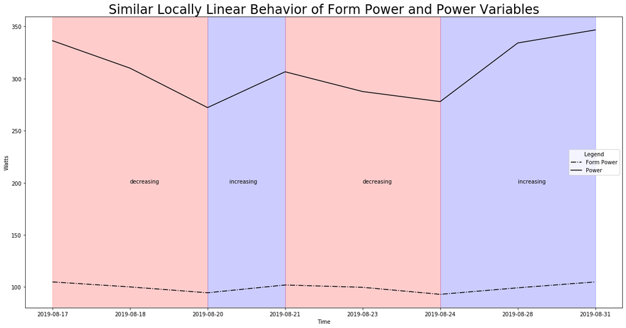

```python
plt.figure(figsize=(20,10))
plt.plot(dfgrouped['Form Power'].dropna(), label='Form Power', color='black', linestyle='-.')
plt.plot(dfgrouped['Power'].dropna(), label='Power', color='black')
globminPower = (dfgrouped['Power'].dropna()).argmin()
globmaxPower = (dfgrouped['Power'].dropna()).argmax()
globminFPower = (dfgrouped['Form Power'].dropna()).argmin()
globmaxFPower = (dfgrouped['Form Power'].dropna()).argmax()

plt.axvspan('2019-08-17', globminPower, color='red', alpha=0.2)
plt.axvspan(globminFPower, globmaxPower, color='blue', alpha=0.2)
plt.axvspan('2019-08-20', '2019-08-21', color='blue', alpha=0.2)
plt.axvspan('2019-08-21', '2019-08-24', color='red', alpha=0.2)


plt.title('Similar Locally Linear Behavior of Form Power and Power Variables', fontsize=24)
plt.xlabel('Time')
plt.ylabel('Watts')
plt.legend(title='Legend')
plt.text('2019-08-18', 200, 'decreasing')
plt.text('2019-08-28', 200, 'increasing')
plt.text('2019-08-20', 200, '             increasing')
plt.text('2019-08-23', 200, 'decreasing')
plt.show()
```

The time series plot above shows that, at least on average, `Form Power` and `Power` are tracking the same as suggested by the box plots highlighted in Maize. During workouts where `Form Power` is low, `Power` is also low, and the line graph has nearly identical locally linear behavior, including precise inflection points from increasing to decreasing.

Since we are intent on exploring shared behaviors between variables, perhaps we could look at how each Strava variable is correlated with each other variable. Seaborn provides the quickest and easiest tool to explore these correlations:

## Visualization 3: Heatmap

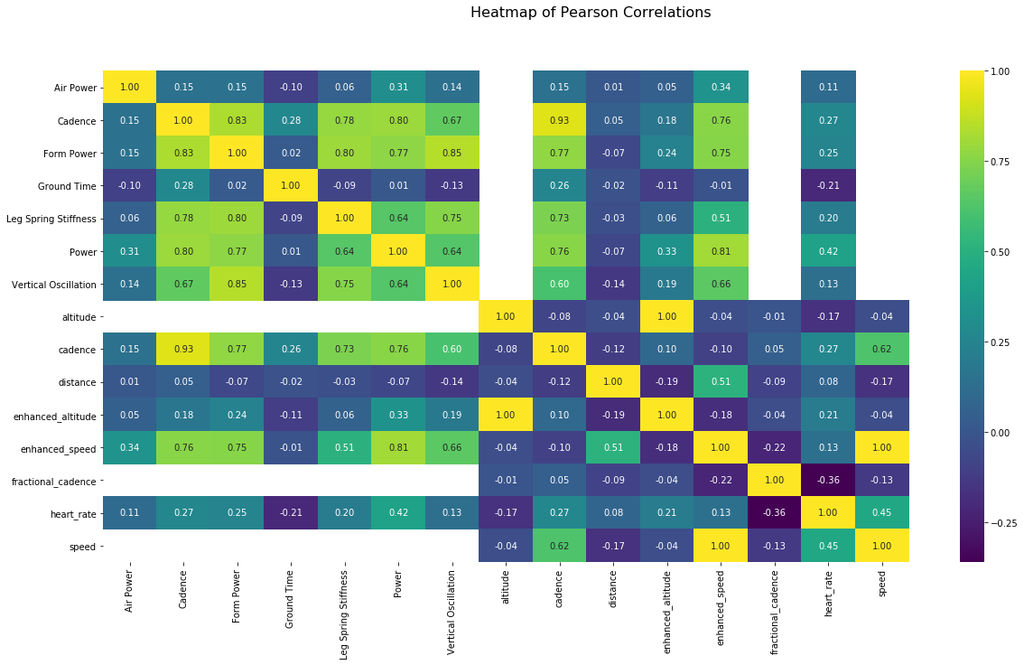

```python
plt.figure(figsize=(20, 10))
plt.suptitle('Heatmap of Pearson Correlations', fontsize=16)
sns.heatmap(df.drop(['unknown_87', 'unknown_88', 'unknown_90', 'position_lat', 'position_long'],
                    axis=1).corr(), annot=True, fmt=".2f", cmap="viridis")
plt.show()
```

Note above that we are dropping some columns that don't have particular import to our analysis with the pandas `.drop()` method, as well as using the pandas `.corr()` method on our dataframe as we pass our data into the `.heatmap()` method of Seaborn. The `annot` argument is perhaps the star of the method, since this automatically populates the numerical data (in this case, Pearson correlation coefficients) to label each cell in the heat map. The string formatting argument `fmt` is used to tidy up the coefficients to being reported to two decimal places.

Among the highest correlated variables are `Vertical Oscillation` and `Form Power` (corr = 0.85), which is congruent with the monitor's statement that "you will see form power trend very closely to your vertical oscillation." Also among the highest correlated variables at 0.77, are our `Form Power` and `Power` variables previously discussed.

Returning to the information about overall shape of the data from the boxplots above, we can see a significant amount of variability in the variables `distance` and `enhanced_speed` (shaded blue). For these variables, the variability is so visually evident because the range from lowest to highest value is large. Recalling that the value of monitoring fitness data is from session to session over time, we can group the data by day of the week and average the variables over these days of the week to explore how the activities change from day-to-day during a typical week.

## Data Manipulation, Part 2: Preparing Data for Time Series Analysis

For this exploration, we will significantly change our DataFrame, so we will define a copy as `dayofweek`:

```python
dayofweek = df.copy()
```

Next, we will transform our previously defined `date` variable from the `timestamp` variable as a DateTime Object with a lambda function, and set this as `dayofweek` DataFrame's index:

```python
dayofweek['dateobj'] = dayofweek['date'].apply(lambda x: pd.to_datetime(x, format='%Y-%m-%d'))
dayofweek.set_index(dayofweek.dateobj, inplace=True)
dayofweek.set_index(pd.to_datetime(dayofweek.index), drop=True, inplace=True)
```

Setting the DateTime Object as the index allows us to define a new column, `dow`, where we map each row of data to an integer day of the week (that starts with Monday and ends with Sunday, 0 through 6) by using the `.weekday()` method:

```python
dayofweek['dow'] = dayofweek.index.map(lambda y: y.weekday)
```

Now we group our data based on `dow` and apply the `.mean()` method to each of the variable's values tabulated under that numeric day of the week:

```python
dayofweek_grouped = dayofweek.groupby('dow').mean()
dayofweek_grouped
```

| dow | Air Power | Cadence | Form Power | Ground Time | Leg Spring Stiffness | Power | Vertical Oscillation | altitude | cadence | distance | enhanced_altitude | enhanced_speed | fractional_cadence | heart_rate | position_lat | position_long | speed | unknown_87 | unknown_88 | unknown_90 |
| --- | --- | --- | --- | --- | --- | --- | --- | --- | --- | --- | --- | --- | --- | --- | --- | --- | --- | --- | --- | --- |
| 0 | NaN | NaN | NaN | NaN | NaN | NaN | NaN | 3869.566351 | 69.262555 | 10416.808765 | 263.109508 | 5.036650 | 0.053023 | 123.561088 | 5.047014e+08 | -9.995478e+08 | 2095.687155 | 0.0 | 297.316384 | -0.226293 |
| 1 | 1.498781 | 75.714254 | 94.514077 | 338.423853 | 12.996509 | 272.080692 | 6.074651 | 3871.729412 | 76.086228 | 2397.679995 | 254.723574 | 2.228350 | 0.024970 | 137.076378 | 5.044585e+08 | -9.988820e+08 | 2205.006270 | 0.0 | 299.066874 | -0.011156 |
| 2 | 2.199753 | 78.746609 | 101.533292 | 321.691739 | 13.322698 | 310.979860 | 6.616651 | 3826.794466 | 69.016298 | 2629.403780 | 278.851149 | 2.875615 | 0.044063 | 143.642010 | 5.045178e+08 | -9.992566e+08 | 2267.246354 | 0.0 | 297.456162 | -3.169063 |
| 3 | NaN | NaN | NaN | NaN | NaN | NaN | NaN | 3839.213505 | 67.381999 | 7849.275590 | 262.511937 | 3.871954 | 0.105704 | 125.736594 | 5.045582e+08 | -9.994013e+08 | 1830.545364 | 0.0 | 298.953701 | -1.261818 |
| 4 | 0.712038 | 77.936271 | 99.751377 | 336.362707 | 13.444729 | 287.465775 | 6.492771 | 3858.615215 | 75.652616 | 3392.020878 | 281.351537 | 2.183102 | 0.119809 | 129.597176 | 5.045433e+08 | -9.992217e+08 | 1989.108619 | 0.0 | 298.754153 | -0.807488 |
| 5 | 2.620057 | 78.468540 | 101.757236 | 313.262879 | 12.940022 | 324.511301 | 6.612884 | 3875.482018 | 75.711185 | 3270.511915 | 281.844728 | 3.177414 | 0.054260 | 139.469852 | 5.045768e+08 | -1.000639e+09 | 2032.359491 | 0.0 | 299.241989 | -0.042576 |
| 6 | 1.251721 | 77.664700 | 100.122911 | 325.954769 | 13.080261 | 309.887906 | 6.565757 | 3817.359461 | 74.643482 | 2592.876551 | 262.951554 | 2.531269 | 0.136506 | 125.829683 | 5.044608e+08 | -9.990648e+08 | 2073.037569 | 0.0 | 298.415657 | -0.782523 |

## Visualization 4: Bar Chart / Time Series

Continuing with the theme of using handily available methods at our disposal, we will call the pandas `.plot()` method to create some bar charts:

Before proceeding, we must define a list of `days` of the week that will be used to annotate the x-axes tick marks to refine our current numerical representation of day of the week, as well as a color scheme for the days of the week:

```python
days = ['Mon', 'Tue', 'Wed', 'Thu', 'Fri', 'Sat', 'Sun']
rainbow = ['red', 'orange', 'yellow', 'green', 'blue', 'indigo', 'violet']
```

(01) First, we create a Matplotlib subplot array of axes,  
(02) Then use the pandas `.plot()` method directly on columns of our data, assigning the plot to a subplot of axes, and colorizing the chart.  
(03) Finally, we annotate the plot with Matplotlib axes methods  
(04) " "  
(05) " "  
(06) " "

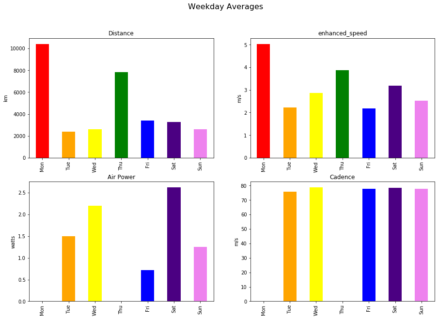

```python
fig, axes = plt.subplots(ncols=2, nrows=2)
dayofweek_grouped['distance'].plot(kind = 'bar', ax = axes[0,0], figsize = (15,10), color = rainbow)
axes[0,0].set_xticklabels(days)
axes[0,0].set_title('Distance')
axes[0,0].set_xlabel('')
axes[0,0].set_ylabel('km')
dayofweek_grouped['enhanced_speed'].plot(kind='bar', ax=axes[0,1], figsize=(15,10), color = rainbow)
axes[0,1].set_xticklabels(days)
axes[0,1].set_title('enhanced_speed')
axes[0,1].set_xlabel('')
axes[0,1].set_ylabel('m/s')
dayofweek_grouped['Air Power'].plot(kind='bar', ax=axes[1,0], figsize=(15,10), color = rainbow)
axes[1,0].set_xticklabels(days)
axes[1,0].set_title('Air Power')
axes[1,0].set_xlabel('')
axes[1,0].set_ylabel('watts')
dayofweek_grouped['Cadence'].plot(kind='bar', ax=axes[1,1], figsize=(15,10), color = rainbow)
axes[1,1].set_xticklabels(days)
axes[1,1].set_title('Cadence')
axes[1,1].set_xlabel('')
axes[1,1].set_ylabel('m/s')
fig.suptitle('Weekday Averages', fontsize=16)
plt.show()
```

While we cannot be certain, the Monday and Thursday `distance` and `enhanced_speed` seem more indicative of a cycling exercise than that of a running exercise. To bolster this assertion, we can turn to two other variables that have wide ranges in the boxplots above, `Air Power` and `Cadence`. These variables were monitored with a device that is generally more suitable for running exercises rather than cycling - and data seems absent on Monday and Thursday in plots of these variables as seen above.

Other information gleaned from this exploration include:

- Week-end runs are, on average, longer than runs at the beginning of the week.
- Saturday runs are, on average, faster than runs on other days.
- Monday exercises are, on average, longer and faster than those on Thursday (or any other day of the week, for that matter)

While bar charts are not an unacceptable way to represent the evidence for the assertions about `distance` and `enhanced_speed` above, we can use the information gleaned from the missing `Air Power` or `Cadence` data above to conditionally categorize our data so that we may compare distributions of `distance` and `enhanced_speed` rather than basic categorization based on means offered by the bar charts.

## Visualization 5: Histograms

Here we will use histograms to compare the distribution of two variables, `Distance` and `enhanced_speed`, between two categories: `cycling` and `running`:  
(01) First, we create a Matplotlib subplot array of axes,  
(02) Then provide variable vector including only cycling data by conditionally filtering with `Air Power` variable missing, using `.isnull()` method; set the range from 0 to the maximum distance measured; colorize; label.  
(03) Similarly to prior line, except including only running data by conditionall filtering with `Air Power` variable populated, using `.notnull()` method.  
(03) Finally, we annotate the plot with Matplotlib axes methods  
(04) " "  
(05) " "  
(06) " "

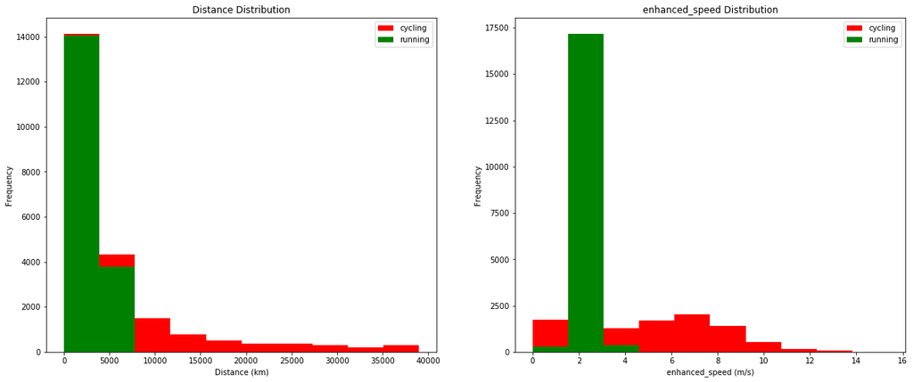

```python
fig, ax = plt.subplots(ncols=2, figsize=(20,8))

ax[0].hist(df['distance'].dropna().where(df['Air Power'].isnull()), range=[0, df['distance'].max()],
             color='red', label='cycling')
ax[0].hist(df['distance'].dropna().where(df['Air Power'].notnull()), range=[0, df['distance'].max()],
            color='green', label='running')
ax[0].set_title('Distance Distribution')
ax[0].set_ylabel('Frequency')
ax[0].set_xlabel('Distance (km)')
ax[0].legend()

ax[1].hist(df['enhanced_speed'].dropna().where(df['Air Power'].isnull()), range=[0, df['enhanced_speed'].max()],
            color='red', label='cycling')
ax[1].hist(df['enhanced_speed'].dropna().where(df['Air Power'].notnull()), range=[0, df['enhanced_speed'].max()],
            color='green', label='running')
ax[1].set_title('enhanced_speed Distribution')
ax[1].set_ylabel('Frequency')
ax[1].set_xlabel('enhanced_speed (m/s)')
ax[1].legend()
plt.show()
```